# Welcome

A first post using Quarto

Quarto

Julia

Find out more about the tools I’m using to create this blog.

Author

Simon Ghyselincks

Published

April 22, 2024

This year, I have been expanding my knowledge of publishing and coding techniques that are designed to make sharing technical work easier, more visual, and more interactive. [Michael Friedlander](https://friedlander.io/), who teaches CPSC 406 Computational Optimization at UBC, is an advocate for using Julia and Quarto in teaching and research. Drawing inspiration from his work along with [Patrick Altmeyer](https://www.paltmeyer.com/blog/)’s website, I have decided to start my own blog using Quarto.

[Quarto](https://quarto.org/) is a scientific and technical publishing system built on Pandoc. It is designed to make it easy to write and publish technical content, such as research papers, books, and reports. One of its main features is that it allows for writing content in markdown along with code chunks in Julia, Python, R, and other languages. In addition, Quarto supports a wide range of output formats, including HTML, PDF, and Word. It has the great convenience of being able to port writing from [Obsidian](https://obsidian.md/) or in [Latex](https://www.latex-project.org/) to a blog post or html with minimal effort.

I’m excited to use this new tool to share my work and ideas, especially as I continue to learn more about data science, machine learning, and optimization. I hope you find the content here useful and/or interesting.

## Examples of Julia Code and Plots

Here’s a parametrically defined, snail-like surface. Although it exists in 3D space, the surface is two-dimensional in that any location on it can be specified using just two coordinates—similar to how we navigate the surface of the Earth. You van see this incorporated as the two parameters $u$ and $v$ in the code below. These two coordinates map into 3D space that is defined by the functions $s1$, $s2$, and $s3$ giving a vector
$$\mathbf{s}(u,v) = \begin{bmatrix}s1(u,v) \\ s2(u,v) \\ s3(u,v)\end{bmatrix}$$

The surface is then plotted using the `surface` function from the Julia Plots package.

Note the usage of the vectorized operation of the functions $s1$, $s2$, and $s3$ to create the vectors `xs`, `ys`, and `zs`. The passing of the input vectors `u` and `v'` creates the required meshgrid for the surface plot.

```julia
using Plots

# Your plotting code here
u = range(0, stop=6π, length=100)
v = range(0, stop=2π, length=30)
s1(u, v) = 2 * (1 - exp(u / (6 * π))) * cos(u) * cos(v / 2)^2
s2(u, v) = 2 * (-1 + exp(u / (6 * π))) * sin(u) * cos(v / 2)^2
s3(u, v) = 1 - 0.71 * exp(u / (3 * π)) - sin(v) + exp(u / (6 * π)) * sin(v)

xs, ys, zs = s1.(u, v'), s2.(u, v'), s3.(u, v')
surface(xs, ys, zs, color=cgrad(:acton), alpha=0.5, legend=false)
```

[figure not shown]

Figure 1: Surface Plot Example

This code is an example of the animation features included in the Julia Plot library found at [Julia Plots Package](https://docs.juliaplots.org/stable/animations/) that can be used to create a gif. The gif below shows a parametric plot of a heart. Note just how compact the code is for creating this gif and the natural expression that the code has. This is the power of Julia.

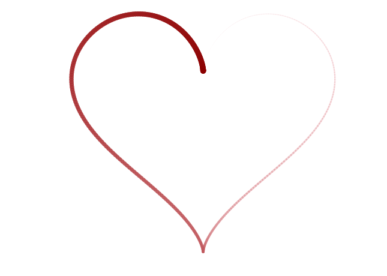

Figure 2: Heart Animation Example

```julia
using Plots

@userplot CirclePlot
@recipe function f(cp::CirclePlot)
    x, y, i = cp.args
    n = length(x)
    inds = circshift(1:n, 1 - i)
    linewidth --> range(0, 10, length = n)
    seriesalpha --> range(0, 1, length = n)
    aspect_ratio --> 1
    label --> false
    x[inds], y[inds]
end

n = 400
t = range(0, 2π, length = n)
x = 16sin.(t).^3
y = 13cos.(t) .- 5cos.(2t) .- 2cos.(3t) .- cos.(4t)

anim = @animate for i ∈ 1:n
    circleplot(x, y, i, line_z = 1:n, cbar = false, c = :reds, framestyle = :none)
end every 5
gif(anim, "anim_fps15.gif", fps = 15, show_msg = false)
```